# DS-PATH & REU R/dplyr Workshop

Wenxiu Ma

2024-JUN-24

# Load the `tidyverse` package

**Install the package necessary packages**

Note that you only need to install each package once. Then you can comment out the following installation lines.

```r
# install.packages("tidyverse")
# install.packages("maps")
# install.packages("mapproj")
```

**Load necessary packages**

```r
# load the package before usage
library(tidyverse) # for `ggplot2`, `dplyr`, `tibble`, `readr`, `purrr`, and `dplyr`
library(nycflights13) # for the 2013 NYC flights data set

library(maps) # for map visualization
library(mapproj)
```

## Set the working directory

# Useful tutorials and reference sheets

## “**R for Data Science**” by Grolemund and Wickham

- Online textbook availabel at http://r4ds.had.co.nz/

## RStudio Cheat Sheets

Latest cheat sheets available at https://www.rstudio.com/resources/cheatsheets/

- [RStudio IDE Cheat Sheet](https://raw.githubusercontent.com/rstudio/cheatsheets/main/rstudio-ide.pdf)
- [R Markdown Cheat Sheet](https://raw.githubusercontent.com/rstudio/cheatsheets/main/rmarkdown.pdf)
- [Data Visualization Cheat Sheet](https://raw.githubusercontent.com/rstudio/cheatsheets/main/data-visualization.pdf)
- [Data Transformation Cheat Sheet](https://raw.githubusercontent.com/rstudio/cheatsheets/main/data-transformation.pdf)
- [Data tidying Cheat Sheet](https://raw.githubusercontent.com/rstudio/cheatsheets/main/tidyr.pdf)
- [Data Import Cheat Sheet](https://raw.githubusercontent.com/rstudio/cheatsheets/main/data-import.pdf)
- [Work with Strings Cheat Sheet](https://raw.githubusercontent.com/rstudio/cheatsheets/main/strings.pdf)
- [Dates and Times Cheat Sheet](https://raw.githubusercontent.com/rstudio/cheatsheets/main/lubridate.pdf)

# Typical data science project workflow

## Data wrangling

First step is data wrangling. That is, getting your data into R in a useful form for visualization and modeling.

## Data exploration/visualization

Next step is data exploration. Data exploration is the art of looking at your data, rapidly generating hypotheses, quickly testing them, then repeating again and again and again.

## Presenting your findings

Lastly, you need to communicate your results! It doesn’t matter how great your analysis is unless you can explain it to others.

# The `nycflights13::flights` data set

This data frame contains all 336,776 flights that departed from New York City in 2013. The data comes from the [US Bureau of Transportation Statistics](http://www.transtats.bts.gov/DatabaseInfo.asp?DB_ID=120&Link=0).

```r
# You only need to install it once. Note that the eval option of this chuck is set to F.
install.packages("nycflights13")
```

```r
library(nycflights13)
help(package="nycflights13")
?flights # full documentation of flights
# View(flights) # see the data in RStudio Viewer
flights
```

```
## # A tibble: 336,776 × 19
##     year month   day dep_time sched_dep_time dep_delay arr_time sched_arr_time
##    <int> <int> <int>    <int>          <int>     <dbl>    <int>          <int>
##  1  2013     1     1      517            515         2      830            819
##  2  2013     1     1      533            529         4      850            830
##  3  2013     1     1      542            540         2      923            850
##  4  2013     1     1      544            545        -1     1004           1022
##  5  2013     1     1      554            600        -6      812            837
##  6  2013     1     1      554            558        -4      740            728
##  7  2013     1     1      555            600        -5      913            854
##  8  2013     1     1      557            600        -3      709            723
##  9  2013     1     1      557            600        -3      838            846
## 10  2013     1     1      558            600        -2      753            745
## # ℹ 336,766 more rows
## # ℹ 11 more variables: arr_delay <dbl>, carrier <chr>, flight <int>,
## #   tailnum <chr>, origin <chr>, dest <chr>, air_time <dbl>, distance <dbl>,
## #   hour <dbl>, minute <dbl>, time_hour <dttm>
```

# What can you do with `dplyr`?

- Pick observations by their values - `filter()’
- Reorder the rows - `arrange()`
- Pick variables by their names - `select()`
- Create new variables with functions of existing variables - `mutate()`
- Collapse many values down to a single summary - `summarise()`
- The above five can be used in conjunction with `group_by()` which changes the scope of each function from operating on the entire dataset to operating on it group-by-group.

These six functions provide the verbs for a language of **data manipulation/wrangling**.

## Pick observations by their values - `filter()`

`filter()` allows you to subset observations based on their values.

- The first argument is the name of the data frame.
- The second and subsequent arguments are the expressions that filter the data frame.

```r
# flights that departed on Jan/1/2013
# print out the new data frame only
filter(flights, month == 1, day == 1)
```

```
## # A tibble: 842 × 19
##     year month   day dep_time sched_dep_time dep_delay arr_time sched_arr_time
##    <int> <int> <int>    <int>          <int>     <dbl>    <int>          <int>
##  1  2013     1     1      517            515         2      830            819
##  2  2013     1     1      533            529         4      850            830
##  3  2013     1     1      542            540         2      923            850
##  4  2013     1     1      544            545        -1     1004           1022
##  5  2013     1     1      554            600        -6      812            837
##  6  2013     1     1      554            558        -4      740            728
##  7  2013     1     1      555            600        -5      913            854
##  8  2013     1     1      557            600        -3      709            723
##  9  2013     1     1      557            600        -3      838            846
## 10  2013     1     1      558            600        -2      753            745
## # ℹ 832 more rows
## # ℹ 11 more variables: arr_delay <dbl>, carrier <chr>, flight <int>,
## #   tailnum <chr>, origin <chr>, dest <chr>, air_time <dbl>, distance <dbl>,
## #   hour <dbl>, minute <dbl>, time_hour <dttm>
```

```r
# save the new data frame to a variable, no print out
jan1 <- filter(flights, month == 1, day == 1)

# save and print out the new data frame
(jan1 <- filter(flights, month == 1, day == 1))
```

```
## # A tibble: 842 × 19
##     year month   day dep_time sched_dep_time dep_delay arr_time sched_arr_time
##    <int> <int> <int>    <int>          <int>     <dbl>    <int>          <int>
##  1  2013     1     1      517            515         2      830            819
##  2  2013     1     1      533            529         4      850            830
##  3  2013     1     1      542            540         2      923            850
##  4  2013     1     1      544            545        -1     1004           1022
##  5  2013     1     1      554            600        -6      812            837
##  6  2013     1     1      554            558        -4      740            728
##  7  2013     1     1      555            600        -5      913            854
##  8  2013     1     1      557            600        -3      709            723
##  9  2013     1     1      557            600        -3      838            846
## 10  2013     1     1      558            600        -2      753            745
## # ℹ 832 more rows
## # ℹ 11 more variables: arr_delay <dbl>, carrier <chr>, flight <int>,
## #   tailnum <chr>, origin <chr>, dest <chr>, air_time <dbl>, distance <dbl>,
## #   hour <dbl>, minute <dbl>, time_hour <dttm>
```

```r
# flights that departed in Nov or Dec
filter(flights, month == 11 | month == 12)
```

```
## # A tibble: 55,403 × 19
##     year month   day dep_time sched_dep_time dep_delay arr_time sched_arr_time
##    <int> <int> <int>    <int>          <int>     <dbl>    <int>          <int>
##  1  2013    11     1        5           2359         6      352            345
##  2  2013    11     1       35           2250       105      123           2356
##  3  2013    11     1      455            500        -5      641            651
##  4  2013    11     1      539            545        -6      856            827
##  5  2013    11     1      542            545        -3      831            855
##  6  2013    11     1      549            600       -11      912            923
##  7  2013    11     1      550            600       -10      705            659
##  8  2013    11     1      554            600        -6      659            701
##  9  2013    11     1      554            600        -6      826            827
## 10  2013    11     1      554            600        -6      749            751
## # ℹ 55,393 more rows
## # ℹ 11 more variables: arr_delay <dbl>, carrier <chr>, flight <int>,
## #   tailnum <chr>, origin <chr>, dest <chr>, air_time <dbl>, distance <dbl>,
## #   hour <dbl>, minute <dbl>, time_hour <dttm>
```

```r
filter(flights, month %in% c(11, 12))
```

```
## # A tibble: 55,403 × 19
##     year month   day dep_time sched_dep_time dep_delay arr_time sched_arr_time
##    <int> <int> <int>    <int>          <int>     <dbl>    <int>          <int>
##  1  2013    11     1        5           2359         6      352            345
##  2  2013    11     1       35           2250       105      123           2356
##  3  2013    11     1      455            500        -5      641            651
##  4  2013    11     1      539            545        -6      856            827
##  5  2013    11     1      542            545        -3      831            855
##  6  2013    11     1      549            600       -11      912            923
##  7  2013    11     1      550            600       -10      705            659
##  8  2013    11     1      554            600        -6      659            701
##  9  2013    11     1      554            600        -6      826            827
## 10  2013    11     1      554            600        -6      749            751
## # ℹ 55,393 more rows
## # ℹ 11 more variables: arr_delay <dbl>, carrier <chr>, flight <int>,
## #   tailnum <chr>, origin <chr>, dest <chr>, air_time <dbl>, distance <dbl>,
## #   hour <dbl>, minute <dbl>, time_hour <dttm>
```

```r
# flights that weren't delayed (on arrival or departure) by more than two hours
filter(flights, !(arr_delay > 120 | dep_delay > 120))
```

```
## # A tibble: 316,050 × 19
##     year month   day dep_time sched_dep_time dep_delay arr_time sched_arr_time
##    <int> <int> <int>    <int>          <int>     <dbl>    <int>          <int>
##  1  2013     1     1      517            515         2      830            819
##  2  2013     1     1      533            529         4      850            830
##  3  2013     1     1      542            540         2      923            850
##  4  2013     1     1      544            545        -1     1004           1022
##  5  2013     1     1      554            600        -6      812            837
##  6  2013     1     1      554            558        -4      740            728
##  7  2013     1     1      555            600        -5      913            854
##  8  2013     1     1      557            600        -3      709            723
##  9  2013     1     1      557            600        -3      838            846
## 10  2013     1     1      558            600        -2      753            745
## # ℹ 316,040 more rows
## # ℹ 11 more variables: arr_delay <dbl>, carrier <chr>, flight <int>,
## #   tailnum <chr>, origin <chr>, dest <chr>, air_time <dbl>, distance <dbl>,
## #   hour <dbl>, minute <dbl>, time_hour <dttm>
```

```r
filter(flights, arr_delay <= 120, dep_delay <= 120)
```

```
## # A tibble: 316,050 × 19
##     year month   day dep_time sched_dep_time dep_delay arr_time sched_arr_time
##    <int> <int> <int>    <int>          <int>     <dbl>    <int>          <int>
##  1  2013     1     1      517            515         2      830            819
##  2  2013     1     1      533            529         4      850            830
##  3  2013     1     1      542            540         2      923            850
##  4  2013     1     1      544            545        -1     1004           1022
##  5  2013     1     1      554            600        -6      812            837
##  6  2013     1     1      554            558        -4      740            728
##  7  2013     1     1      555            600        -5      913            854
##  8  2013     1     1      557            600        -3      709            723
##  9  2013     1     1      557            600        -3      838            846
## 10  2013     1     1      558            600        -2      753            745
## # ℹ 316,040 more rows
## # ℹ 11 more variables: arr_delay <dbl>, carrier <chr>, flight <int>,
## #   tailnum <chr>, origin <chr>, dest <chr>, air_time <dbl>, distance <dbl>,
## #   hour <dbl>, minute <dbl>, time_hour <dttm>
```

### Missing values - `NA` (“not available”)

`NA` represents an unknown value so missing values are “contagious”

- Almost any operation involving an unknown value will also be unknown.

```r
NA > 5
```

```
## [1] NA
```

```r
10 == NA
```

```
## [1] NA
```

```r
NA + 10
```

```
## [1] NA
```

```r
NA / 2
```

```
## [1] NA
```

```r
NA == NA
```

```
## [1] NA
```

- If you want to determine if a value is missing, use `is.na()`

```r
x <- NA
is.na(x)
```

```
## [1] TRUE
```

### `filter()` with `NA` values

- `filter()` only includes rows where the condition is TRUE
- It excludes both FALSE and `NA` values.
- If you want to preserve missing values, ask for them explicitly:

```r
(df <- tibble(x = c(1, NA, 3)))
```

```
## # A tibble: 3 × 1
##       x
##   <dbl>
## 1     1
## 2    NA
## 3     3
```

```r
filter(df, x > 1)
```

```
## # A tibble: 1 × 1
##       x
##   <dbl>
## 1     3
```

```r
filter(df, is.na(x) | x > 1)
```

```
## # A tibble: 2 × 1
##       x
##   <dbl>
## 1    NA
## 2     3
```

### Count the number of `NA`s

```r
(df <- tibble(x = c(1, NA, 3, NA)))
```

```
## # A tibble: 4 × 1
##       x
##   <dbl>
## 1     1
## 2    NA
## 3     3
## 4    NA
```

```r
filter(df, is.na(x)) %>% count()
```

```
## # A tibble: 1 × 1
##       n
##   <int>
## 1     2
```

### **Exercise #1**

1. Find the flights that departed in the summer (July, August, and September)

2. Find the flights that flew to Houston (IAH or HOU)

## Combine multiple operations with the pipe `%>%`

- Piping focuses on the transformations, not what’s being transformed, which makes the code easier to read.
- `x %>% f(y)` turns into `f(x, y)`, and `x %>% f(y) %>% g(z)` turns into `g(f(x, y), z)` and so on

```r
df <- tibble(x = c(1, NA, 3, NA))

# step-by-step transformation
df_na <- filter(df, is.na(x))
count(df_na)
```

```
## # A tibble: 1 × 1
##       n
##   <int>
## 1     2
```

```r
# PIPING
# filter(df, is.na(x)) %>% count()
df %>% filter(is.na(x)) %>% count()
```

```
## # A tibble: 1 × 1
##       n
##   <int>
## 1     2
```

## Reorder the rows - `arrange()`

- `arrange()` takes a data frame and a set of column names (or more complicated expressions) to order by.
- When more than one column name are given, each additional column will be used to break ties in the values of preceding columns.

```r
# sort flights by date
arrange(flights, year, month, day)
```

```
## # A tibble: 336,776 × 19
##     year month   day dep_time sched_dep_time dep_delay arr_time sched_arr_time
##    <int> <int> <int>    <int>          <int>     <dbl>    <int>          <int>
##  1  2013     1     1      517            515         2      830            819
##  2  2013     1     1      533            529         4      850            830
##  3  2013     1     1      542            540         2      923            850
##  4  2013     1     1      544            545        -1     1004           1022
##  5  2013     1     1      554            600        -6      812            837
##  6  2013     1     1      554            558        -4      740            728
##  7  2013     1     1      555            600        -5      913            854
##  8  2013     1     1      557            600        -3      709            723
##  9  2013     1     1      557            600        -3      838            846
## 10  2013     1     1      558            600        -2      753            745
## # ℹ 336,766 more rows
## # ℹ 11 more variables: arr_delay <dbl>, carrier <chr>, flight <int>,
## #   tailnum <chr>, origin <chr>, dest <chr>, air_time <dbl>, distance <dbl>,
## #   hour <dbl>, minute <dbl>, time_hour <dttm>
```

### Descending order - `desc()`

- By default, `arrange()` sorts the columns in an ascending order
- To re-order by a column in descending order, use `desc()`

```r
# sort flight by departure delay in a descending order
arrange(flights, desc(dep_delay))
```

```
## # A tibble: 336,776 × 19
##     year month   day dep_time sched_dep_time dep_delay arr_time sched_arr_time
##    <int> <int> <int>    <int>          <int>     <dbl>    <int>          <int>
##  1  2013     1     9      641            900      1301     1242           1530
##  2  2013     6    15     1432           1935      1137     1607           2120
##  3  2013     1    10     1121           1635      1126     1239           1810
##  4  2013     9    20     1139           1845      1014     1457           2210
##  5  2013     7    22      845           1600      1005     1044           1815
##  6  2013     4    10     1100           1900       960     1342           2211
##  7  2013     3    17     2321            810       911      135           1020
##  8  2013     6    27      959           1900       899     1236           2226
##  9  2013     7    22     2257            759       898      121           1026
## 10  2013    12     5      756           1700       896     1058           2020
## # ℹ 336,766 more rows
## # ℹ 11 more variables: arr_delay <dbl>, carrier <chr>, flight <int>,
## #   tailnum <chr>, origin <chr>, dest <chr>, air_time <dbl>, distance <dbl>,
## #   hour <dbl>, minute <dbl>, time_hour <dttm>
```

```r
# arrange(flights, desc(year, month, day)) # doesn't work!
arrange(flights, desc(year), desc(month), desc(day))
```

```
## # A tibble: 336,776 × 19
##     year month   day dep_time sched_dep_time dep_delay arr_time sched_arr_time
##    <int> <int> <int>    <int>          <int>     <dbl>    <int>          <int>
##  1  2013    12    31       13           2359        14      439            437
##  2  2013    12    31       18           2359        19      449            444
##  3  2013    12    31       26           2245       101      129           2353
##  4  2013    12    31      459            500        -1      655            651
##  5  2013    12    31      514            515        -1      814            812
##  6  2013    12    31      549            551        -2      925            900
##  7  2013    12    31      550            600       -10      725            745
##  8  2013    12    31      552            600        -8      811            826
##  9  2013    12    31      553            600        -7      741            754
## 10  2013    12    31      554            550         4     1024           1027
## # ℹ 336,766 more rows
## # ℹ 11 more variables: arr_delay <dbl>, carrier <chr>, flight <int>,
## #   tailnum <chr>, origin <chr>, dest <chr>, air_time <dbl>, distance <dbl>,
## #   hour <dbl>, minute <dbl>, time_hour <dttm>
```

### Reorder the rows with `NA`s

- Missing values are always sorted at the end

```r
df <- tibble(x = c(5, 2, NA))

arrange(df, x)
```

```
## # A tibble: 3 × 1
##       x
##   <dbl>
## 1     2
## 2     5
## 3    NA
```

```r
arrange(df, desc(x))
```

```
## # A tibble: 3 × 1
##       x
##   <dbl>
## 1     5
## 2     2
## 3    NA
```

### **Exercise #2**

1. Find the flights that traveled the shortest distance

2. Find the flights that had the shortest air time

## Pick variables by their names - `select()`

- When you have large dataset (hundreds or more variables), the first challenge is often narrowing in on the variables you’re actually interested in.
- `select()` allows you to rapidly zoom in on a useful subset using operations based on the names of the variables.

```r
# Select columns by name
# select(flights, year, month, day)

# Select all columns between year and day (inclusive)
select(flights, year:day)
```

```
## # A tibble: 336,776 × 3
##     year month   day
##    <int> <int> <int>
##  1  2013     1     1
##  2  2013     1     1
##  3  2013     1     1
##  4  2013     1     1
##  5  2013     1     1
##  6  2013     1     1
##  7  2013     1     1
##  8  2013     1     1
##  9  2013     1     1
## 10  2013     1     1
## # ℹ 336,766 more rows
```

```r
# Remove columns by names
# select(data, -year, -month, -day)

# Select all columns except those from year to day (inclusive)
select(flights, -(year:day))
```

```
## # A tibble: 336,776 × 16
##    dep_time sched_dep_time dep_delay arr_time sched_arr_time arr_delay carrier
##       <int>          <int>     <dbl>    <int>          <int>     <dbl> <chr>
##  1      517            515         2      830            819        11 UA
##  2      533            529         4      850            830        20 UA
##  3      542            540         2      923            850        33 AA
##  4      544            545        -1     1004           1022       -18 B6
##  5      554            600        -6      812            837       -25 DL
##  6      554            558        -4      740            728        12 UA
##  7      555            600        -5      913            854        19 B6
##  8      557            600        -3      709            723       -14 EV
##  9      557            600        -3      838            846        -8 B6
## 10      558            600        -2      753            745         8 AA
## # ℹ 336,766 more rows
## # ℹ 9 more variables: flight <int>, tailnum <chr>, origin <chr>, dest <chr>,
## #   air_time <dbl>, distance <dbl>, hour <dbl>, minute <dbl>, time_hour <dttm>
```

### Rename variables - `rename()`

`rename()`, which is a variant of `select()` that keeps all the variables that aren’t explicitly mentioned.

```r
# select(flights, tail_num = tailnum) # only one variable left
rename(flights, tail_num = tailnum)
```

```
## # A tibble: 336,776 × 19
##     year month   day dep_time sched_dep_time dep_delay arr_time sched_arr_time
##    <int> <int> <int>    <int>          <int>     <dbl>    <int>          <int>
##  1  2013     1     1      517            515         2      830            819
##  2  2013     1     1      533            529         4      850            830
##  3  2013     1     1      542            540         2      923            850
##  4  2013     1     1      544            545        -1     1004           1022
##  5  2013     1     1      554            600        -6      812            837
##  6  2013     1     1      554            558        -4      740            728
##  7  2013     1     1      555            600        -5      913            854
##  8  2013     1     1      557            600        -3      709            723
##  9  2013     1     1      557            600        -3      838            846
## 10  2013     1     1      558            600        -2      753            745
## # ℹ 336,766 more rows
## # ℹ 11 more variables: arr_delay <dbl>, carrier <chr>, flight <int>,
## #   tail_num <chr>, origin <chr>, dest <chr>, air_time <dbl>, distance <dbl>,
## #   hour <dbl>, minute <dbl>, time_hour <dttm>
```

## Create new variables - `mutate()`

- `mutate()` adds new columns with functions of existing columns
- `mutate()` always adds new columns at the end of your dataset

```r
# select a subset of variables to be used in the next step
flights_sml <- select(flights, month:day, ends_with("delay"),
                      distance, air_time)

# create two new variables, gain and speed
mutate(flights_sml,
       gain = arr_delay - dep_delay,
       speed = distance / air_time * 60)
```

```
## # A tibble: 336,776 × 8
##    month   day dep_delay arr_delay distance air_time  gain speed
##    <int> <int>     <dbl>     <dbl>    <dbl>    <dbl> <dbl> <dbl>
##  1     1     1         2        11     1400      227     9  370.
##  2     1     1         4        20     1416      227    16  374.
##  3     1     1         2        33     1089      160    31  408.
##  4     1     1        -1       -18     1576      183   -17  517.
##  5     1     1        -6       -25      762      116   -19  394.
##  6     1     1        -4        12      719      150    16  288.
##  7     1     1        -5        19     1065      158    24  404.
##  8     1     1        -3       -14      229       53   -11  259.
##  9     1     1        -3        -8      944      140    -5  405.
## 10     1     1        -2         8      733      138    10  319.
## # ℹ 336,766 more rows
```

### Create new variables - `transmute()`

If you only want to keep the new variables, use `transmute()`

```r
transmute(flights,
          gain = arr_delay - dep_delay,
          hours = air_time / 60,
          gain_per_hour = gain / hours)
```

```
## # A tibble: 336,776 × 3
##     gain hours gain_per_hour
##    <dbl> <dbl>         <dbl>
##  1     9 3.78           2.38
##  2    16 3.78           4.23
##  3    31 2.67          11.6
##  4   -17 3.05          -5.57
##  5   -19 1.93          -9.83
##  6    16 2.5            6.4
##  7    24 2.63           9.11
##  8   -11 0.883        -12.5
##  9    -5 2.33          -2.14
## 10    10 2.3            4.35
## # ℹ 336,766 more rows
```

```r
transmute(flights, dep_time, hour = dep_time %/% 100,
          minute = dep_time %% 100)
```

```
## # A tibble: 336,776 × 3
##    dep_time  hour minute
##       <int> <dbl>  <dbl>
##  1      517     5     17
##  2      533     5     33
##  3      542     5     42
##  4      544     5     44
##  5      554     5     54
##  6      554     5     54
##  7      555     5     55
##  8      557     5     57
##  9      557     5     57
## 10      558     5     58
## # ℹ 336,766 more rows
```

### **Exercise #3**

Find the fastest flight (i.e., the flight has the highest speed). Report the flight date, actual departure and arrival time, origin, destination, carrier, and flight number.

## Grouped summaries with `summarise()`

- `summarise()` collapses a data frame to a single row

```r
summarise(flights, delay = mean(dep_delay, na.rm = TRUE))
```

```
## # A tibble: 1 × 1
##   delay
##   <dbl>
## 1  12.6
```

- `summarize()` is useful when pair it with `group_by()`

```r
by_day <- group_by(flights, year, month, day)
summarise(by_day, delay = mean(dep_delay, na.rm = TRUE))
## `summarise()` has grouped output by 'year', 'month'. You can override using the
## `.groups` argument.
## # A tibble: 365 × 4
## # Groups:   year, month [12]
##     year month   day delay
##    <int> <int> <int> <dbl>
##  1  2013     1     1 11.5
##  2  2013     1     2 13.9
##  3  2013     1     3 11.0
##  4  2013     1     4  8.95
##  5  2013     1     5  5.73
##  6  2013     1     6  7.15
##  7  2013     1     7  5.42
##  8  2013     1     8  2.55
##  9  2013     1     9  2.28
## 10  2013     1    10  2.84
## # ℹ 355 more rows
```

```r
flights %>% group_by(year, month, day) %>%
  summarise(avg_delay1 = mean(arr_delay, na.rm = T),
            # the average positive delay
            avg_delay2 = mean(arr_delay[arr_delay > 0], na.rm = T))
## `summarise()` has grouped output by 'year', 'month'. You can override using the
## `.groups` argument.
## # A tibble: 365 × 5
## # Groups:   year, month [12]
##     year month   day avg_delay1 avg_delay2
##    <int> <int> <int>      <dbl>      <dbl>
##  1  2013     1     1     12.7         32.5
##  2  2013     1     2     12.7         32.0
##  3  2013     1     3      5.73        27.7
##  4  2013     1     4     -1.93        28.3
##  5  2013     1     5     -1.53        22.6
##  6  2013     1     6      4.24        24.4
##  7  2013     1     7     -4.95        27.8
##  8  2013     1     8     -3.23        20.8
##  9  2013     1     9     -0.264       25.6
## 10  2013     1    10     -5.90        27.3
## # ℹ 355 more rows
```

### Summarise multiple columns

```r
# count # of NAs per column
colSums(is.na(flights))
```

```
##           year          month            day       dep_time sched_dep_time
##              0              0              0           8255              0
##      dep_delay       arr_time sched_arr_time      arr_delay        carrier
##           8255           8713              0           9430              0
##         flight        tailnum         origin           dest       air_time
##              0           2512              0              0           9430
##       distance           hour         minute      time_hour
##              0              0              0              0
```

```r
flights %>% summarise_all(funs(sum(is.na(.)))) %>% print(width=Inf)
```

[output not shown]

### **Exercise #4**

Which carrier had the worst delays over the year?

First filter out all canceled flights; next group by carrier; then calculate average arrival delay per carrier; last, rank your results.

Try to use the pipe `|>` to answer this question.

# Case study - Study average delay per destination

Imagine that we want to explore the relationship between the distance and average delay for each destination.

## Calculate average delay per destination

```r
by_dest <- group_by(flights, dest)
delays_by_dest <- summarise(by_dest, count = n(),
                   dist = mean(distance),
                   delay = mean(arr_delay))
delays_by_dest
```

```
## # A tibble: 105 × 4
##    dest  count  dist delay
##    <chr> <int> <dbl> <dbl>
##  1 ABQ     254 1826   4.38
##  2 ACK     265  199  NA
##  3 ALB     439  143  NA
##  4 ANC       8 3370  -2.5
##  5 ATL   17215  757. NA
##  6 AUS    2439 1514. NA
##  7 AVL     275  584. NA
##  8 BDL     443  116  NA
##  9 BGR     375  378  NA
## 10 BHM     297  866. NA
## # ℹ 95 more rows
```

### How many missing values?

```r
filter(delays_by_dest, is.na(delay))
```

```
## # A tibble: 100 × 4
##    dest  count  dist delay
##    <chr> <int> <dbl> <dbl>
##  1 ACK     265  199     NA
##  2 ALB     439  143     NA
##  3 ATL   17215  757.    NA
##  4 AUS    2439 1514.    NA
##  5 AVL     275  584.    NA
##  6 BDL     443  116     NA
##  7 BGR     375  378     NA
##  8 BHM     297  866.    NA
##  9 BNA    6333  758.    NA
## 10 BOS   15508  191.    NA
## # ℹ 90 more rows
```

```r
colSums(is.na(delays_by_dest)) # count # of NAs per column
```

```
##  dest count  dist delay
##     0     0     0   100
```

### Deal with missing values

1. use `na.rm = TRUE` in the summary function

```r
delays_by_dest1 <- summarise(by_dest, count = n(),
                   dist = mean(distance),
                   delay = mean(arr_delay, na.rm = T))
delays_by_dest1
```

```
## # A tibble: 105 × 4
##    dest  count  dist delay
##    <chr> <int> <dbl> <dbl>
##  1 ABQ     254 1826   4.38
##  2 ACK     265  199   4.85
##  3 ALB     439  143  14.4
##  4 ANC       8 3370  -2.5
##  5 ATL   17215  757. 11.3
##  6 AUS    2439 1514.  6.02
##  7 AVL     275  584.  8.00
##  8 BDL     443  116   7.05
##  9 BGR     375  378   8.03
## 10 BHM     297  866. 16.9
## # ℹ 95 more rows
```

2. filter out missing values from `flights` and use **non-canceled** flights instead

```r
# count # of NAs per column
colSums(is.na(flights))
```

```
##           year          month            day       dep_time sched_dep_time
##              0              0              0           8255              0
##      dep_delay       arr_time sched_arr_time      arr_delay        carrier
##           8255           8713              0           9430              0
##         flight        tailnum         origin           dest       air_time
##              0           2512              0              0           9430
##       distance           hour         minute      time_hour
##              0              0              0              0
```

- `NA`s in `dep_delay` or `arr_delay` represent **canceled** flights

```r
not_canceled <- filter(flights, !is.na(dep_delay), !is.na(arr_delay))
not_canceled
```

```
## # A tibble: 327,346 × 19
##     year month   day dep_time sched_dep_time dep_delay arr_time sched_arr_time
##    <int> <int> <int>    <int>          <int>     <dbl>    <int>          <int>
##  1  2013     1     1      517            515         2      830            819
##  2  2013     1     1      533            529         4      850            830
##  3  2013     1     1      542            540         2      923            850
##  4  2013     1     1      544            545        -1     1004           1022
##  5  2013     1     1      554            600        -6      812            837
##  6  2013     1     1      554            558        -4      740            728
##  7  2013     1     1      555            600        -5      913            854
##  8  2013     1     1      557            600        -3      709            723
##  9  2013     1     1      557            600        -3      838            846
## 10  2013     1     1      558            600        -2      753            745
## # ℹ 327,336 more rows
## # ℹ 11 more variables: arr_delay <dbl>, carrier <chr>, flight <int>,
## #   tailnum <chr>, origin <chr>, dest <chr>, air_time <dbl>, distance <dbl>,
## #   hour <dbl>, minute <dbl>, time_hour <dttm>
```

```r
delays_by_dest2 <- not_canceled %>% group_by(dest) %>%
  summarise(count = n(), dist = mean(distance),
            delay = mean(arr_delay))
delays_by_dest2
```

```
## # A tibble: 104 × 4
##    dest  count  dist delay
##    <chr> <int> <dbl> <dbl>
##  1 ABQ     254 1826   4.38
##  2 ACK     264  199   4.85
##  3 ALB     418  143  14.4
##  4 ANC       8 3370  -2.5
##  5 ATL   16837  757. 11.3
##  6 AUS    2411 1514.  6.02
##  7 AVL     261  584.  8.00
##  8 BDL     412  116   7.05
##  9 BGR     358  378   8.03
## 10 BHM     269  866. 16.9
## # ℹ 94 more rows
```

## First round of `ggplot2` plot

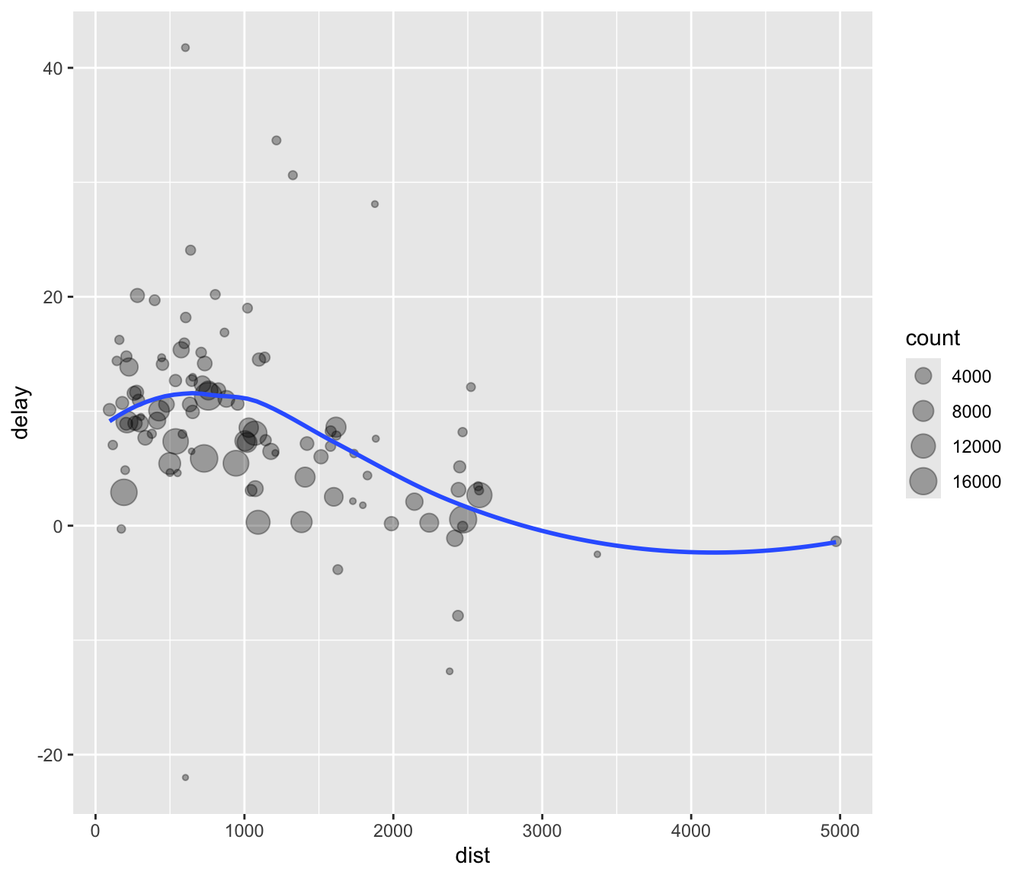

```r
ggplot(data = delays_by_dest2, mapping = aes(x = dist, y = delay)) +
  geom_point(aes(size = count), alpha = 1/3) +
  geom_smooth(se = FALSE)
## `geom_smooth()` using method = 'loess' and formula = 'y ~ x'
```

### What are the two points with largest distances?

```r
arrange(delays_by_dest2, desc(dist))
```

```
## # A tibble: 104 × 4
##    dest  count  dist   delay
##    <chr> <int> <dbl>   <dbl>
##  1 HNL     701 4973. -1.37
##  2 ANC       8 3370  -2.5
##  3 SFO   13173 2578.  2.67
##  4 OAK     309 2576   3.08
##  5 SJC     328 2569   3.45
##  6 SMF     282 2521  12.1
##  7 LAX   16026 2469.  0.547
##  8 BUR     370 2465   8.18
##  9 LGB     661 2465  -0.0620
## 10 PDX    1342 2446.  5.14
## # ℹ 94 more rows
```

```r
top_n(delays_by_dest2, 2, dist)
```

```
## # A tibble: 2 × 4
##   dest  count  dist delay
##   <chr> <int> <dbl> <dbl>
## 1 ANC       8 3370  -2.5
## 2 HNL     701 4973. -1.37
```

### Detect outliers in `delays_by_dest2$dist`

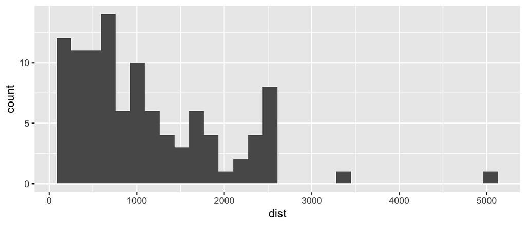

```r
ggplot(data = delays_by_dest2) +
  geom_histogram(mapping = aes(x = dist))
## `stat_bin()` using `bins = 30`. Pick better value with `binwidth`.
```

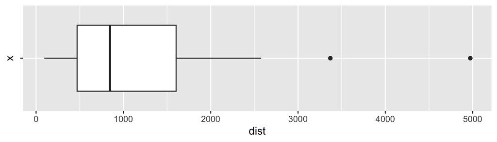

```r
ggplot(data = delays_by_dest2) +
  geom_boxplot(mapping = aes( x = "", y = dist)) +
  coord_flip()
```

## Second round of `ggplot2` plot

### Data transformation & cleaning - step by step

1. Filter out canceled flights;
2. Group non-canceled flights by destination;
3. Summarise grouped data to compute the number of flights, average distance, and average arrival delay per destination;
4. Filter out outliers (longest distances - HNL and ANC);

```r
# original code - step by step
not_canceled <- filter(flights, !is.na(dep_delay), !is.na(arr_delay))
not_canceled_by_dest <-  group_by(not_canceled, dest)
delays_by_dest <- summarise(not_canceled_by_dest, count = n(),
                            dist = mean(distance), delay = mean(arr_delay))
delays_by_dest_cleaned <- filter(delays_by_dest,
                                  dest != "HNL", dest != "ANC")
```

```r
# alternative code using piping %>%
not_canceled <- filter(flights, !is.na(dep_delay), !is.na(arr_delay))
delays_by_dest_cleaned <- not_canceled %>%
  group_by(dest) %>%
  summarise(count = n(), dist = mean(distance), delay = mean(arr_delay)) %>%
  filter(dest != "HNL", dest != "ANC")
```

### Finally, visualization with `ggplot2`

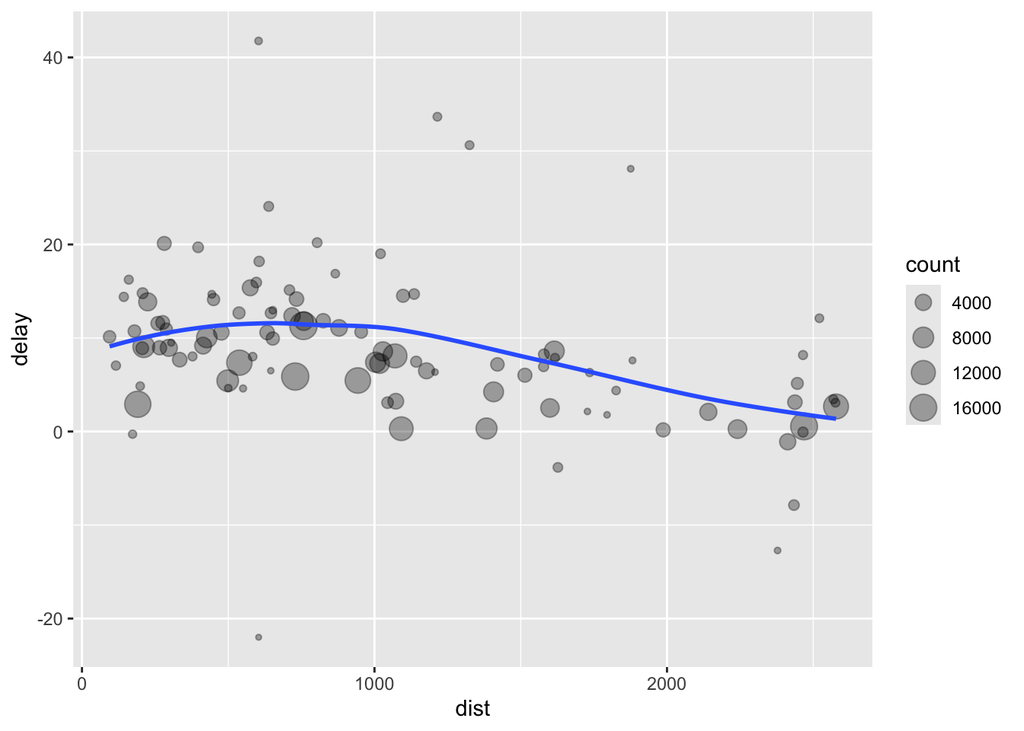

```r
ggplot(data = delays_by_dest_cleaned,
       mapping = aes(x = dist, y = delay)) +
  geom_point(aes(size = count), alpha = 1/3) + geom_smooth(se = F)
## `geom_smooth()` using method = 'loess' and formula = 'y ~ x'
```

### Comparison - original vs cleaned version

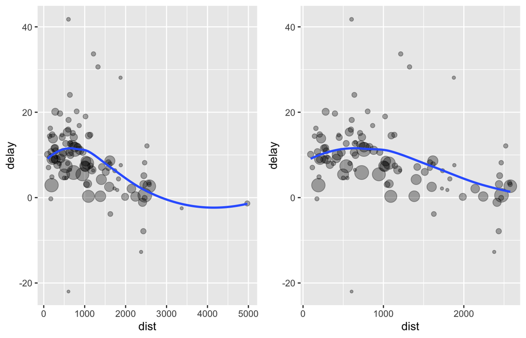